# DE analysis of bulk RNAseq counts of IgG and PD1 mice

Theo Killian

2025-05-21

# Introduction

Bulk RNA-seq was performed to investigate gene expression differences under different conditions. In this report, we describe how we processed the data, performed differential gene expression (DE) analysis, and generated diagnostics and visualizations using the [DESeq2](https://bioconductor.org/packages/release/bioc/html/DESeq2.html) Bioconductor package.

### Analysis Workflow

1. Load Count Data and Metadata
2. Initial Filtering
3. Use `DESeqDataSet` to build a DESeq2 object
4. QC and Exploratory Analysis (PCA, dispersion plots, etc.)
5. Perform Differential Expression
6. Annotation and Result Summaries
7. Visualizations (MA, Volcano and Count Plots and Expression Heatmap)
8. Save Outputs

**NOTE: my bioinformatic interpretations will be displayed in bold**

## Data Preparation

In this section, we load raw count data and sample metadata, and we apply minimal filtering (e.g., removing genes with zero counts across all samples).

### Create Gene Count Matrix using tximport

Our transcript counts derived from Salmon, need to be aggregated by genes. To perform this task, we import and annotate transcript-level counts from Salmon and convert them into a gene-level count matrix using the R package [tximport](https://bioconductor.org/packages/release/bioc/html/tximport.html). We also derive a sample metadata table directly from the count file names, which we will use for differential expression analysis with `DESeq2`.

```r
# Create a TxDb object
txdb <- txdbmaker::makeTxDbFromGFF("./genome/genome.filtered.gtf", format = "gtf")

# Get transcript-to-gene mapping
AnnotationDbi::select(
  txdb, keys = keys(txdb, "TXNAME"),
  columns = "GENEID",
  keytype = "TXNAME") %>%
  as.data.frame() -> tx2gene

readr::write_tsv(tx2gene, file = "./data/tx2gene_mouse.tsv")
```

```r
tx2gene <- readr::read_tsv(file = "./data/tx2gene_mouse.tsv")

# Path to quant.sf files
files <- list.files("./data/counts/", pattern = "quant.sf", full.names = TRUE)

# Sample names
sample_names <- sub(".*/|_quant.sf", "", files)
names(files) <- sample_names

# Import counts
txi <- tximport(files, type = "salmon", tx2gene = tx2gene, countsFromAbundance = "no")
cts <- as.matrix(txi$counts)
cts <- round(cts)
storage.mode(cts) <- "integer" ## coerce to integer so counts play nice with DESeq2
cts <- as.data.frame(cts)
# cts <- as.data.frame(cts) %>%
#   dplyr::select(-contains("PD1_rep1"))
names(cts) <- gsub("results_star_salmon_|_quant\\.sf", "", names(cts))

## make the metadata table directly out of the column names of the count data
data.frame(samples = names(cts),
           condition = gsub("_.*", "", names(cts)),
           replicate = gsub("^[^_]*_", "", names(cts)),
           row.names = names(cts)) %>%
  # dplyr::filter(!grepl("PD1_rep1",  samples)) %>% # |PD1_rep2
  as.data.frame()-> meta_data

# Display a preview of metadata
meta_data %>% DT::datatable(options = list(pageLength = 12))
```

|  | samples | condition | replicate |
| --- | --- | --- | --- |
| IgG_rep1 | IgG_rep1 | IgG | rep1 |
| IgG_rep2 | IgG_rep2 | IgG | rep2 |
| IgG_rep3 | IgG_rep3 | IgG | rep3 |
| IgG_rep4 | IgG_rep4 | IgG | rep4 |
| IgG_rep5 | IgG_rep5 | IgG | rep5 |
| IgG_rep6 | IgG_rep6 | IgG | rep6 |
| PD1_rep1 | PD1_rep1 | PD1 | rep1 |
| PD1_rep2 | PD1_rep2 | PD1 | rep2 |
| PD1_rep3 | PD1_rep3 | PD1 | rep3 |
| PD1_rep4 | PD1_rep4 | PD1 | rep4 |

[output cut: 2 more lines]

## Filter Out Genes with Zero Counts

**NOTE: genes with all zero counts are of no use to us, so we filter them out of the analysis.**

```r
dim(cts) # Before filtering
```

```
#> [1] 45706    12
```

```r
keep <- rowSums(cts) > 0
cts  <- cts[keep, ]
dim(cts) # After filtering
```

```
#> [1] 25873    12
```

## Creating a DESeqDataSet

We construct a `DESeqDataSet` object and specify the design formula. The design formula `~ condition + replicate` indicates that we are modeling gene expression differences by condition, while accounting for batch effects.

**NOTE: This DE comparison is “relative to the IgG condition. This means that genes with positive log fold change display higher average expression in IgG samples, whereas genes with negative log fold change are higher average expression in PD1 samples**

```r
DESeqDataSetFromMatrix(
  countData = cts,
  colData   = meta_data,
  design    = ~ condition + replicate) -> dds

# Quick check of the DESeqDataSet
# dds
```

## Differential Expression Analysis

We run the main DESeq function, which handles size factor estimation, dispersion estimation, and fitting of the negative binomial generalized linear model.

```r
dds <- DESeq(dds)
# resultsNames(dds)
```

## Data exploration and quality assessment (QC)

### Principal components analysis (PCA)

**NOTE: We don’t see strong separation between the IgG and PD1 samples, indicating that there is a lot of inter-condition heterogeneity, and that the biological effect between the conditions is not as strong as sample heterogeneity… at least in the first two principal components/PCs.**

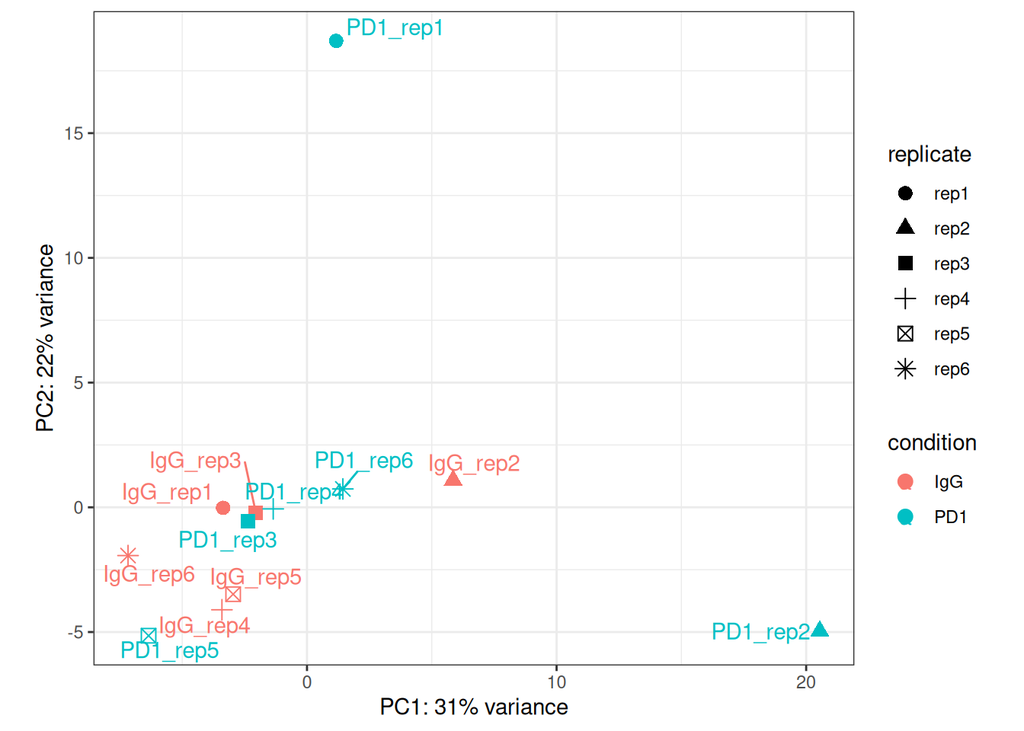

```r
rld_dds <- rlog(dds, blind=FALSE)
pcaData_rld <- plotPCA(rld_dds, intgroup = c("condition", "replicate"), returnData = TRUE)
percentVar <- round(100 * attr(pcaData_rld, "percentVar"))

ggplot(pcaData_rld, aes(PC1, PC2, color = condition, shape = replicate)) +
  geom_point(size = 3) +
  geom_text_repel(aes(label = name), max.overlaps = 15) +
  xlab(paste0("PC1: ", percentVar[1], "% variance")) +
  ylab(paste0("PC2: ", percentVar[2], "% variance")) +
  coord_fixed() +
  theme_bw()
```

### Dispersion Plot

The dispersion estimates are critical for modeling variance in RNA-seq data. The plot below shows the raw gene-wise estimates (black points), the fitted dispersion trend (red line), and final shrunk estimates (blue open circles, if any are outliers).

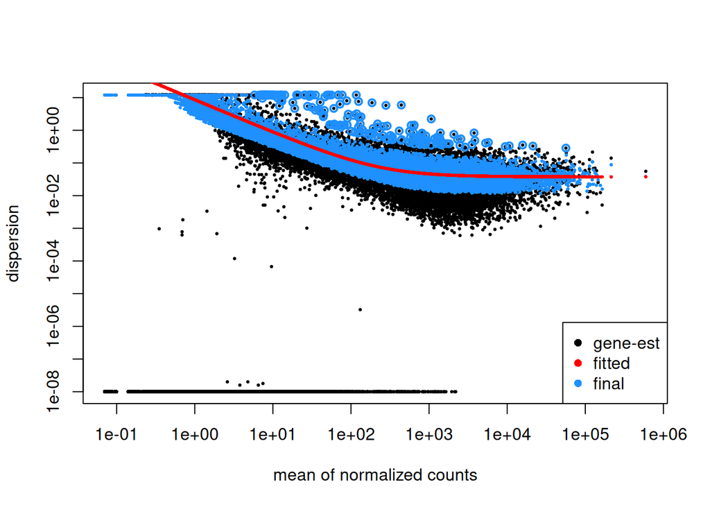

```r
plotDispEsts(dds)
```

### Size factors

Size factors are a method of normalizing used by the *DESeq* function to normalize the data in terms of sequencing depth. Size factor is the median ratio of the sample over a pseudosample: for each gene, the geometric mean of all samples. Size factors account for differences in sequencing depth are typically centered around 1 (indicating comparable sequencing depth).

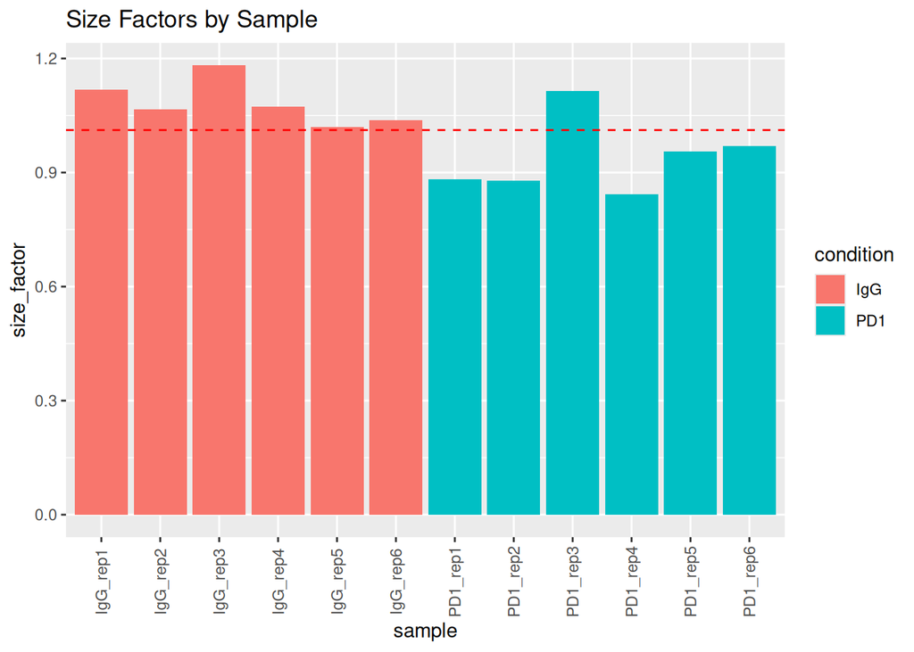

```r
sf_data <- data.frame(sample = rownames(dds@colData),
                      size_factor = sizeFactors(dds),
                      condition = dds$condition,
                      replicate = dds$replicate)

ggplot(sf_data, aes(x = sample, y = size_factor, fill = condition)) +
  geom_bar(stat = "identity") +
  geom_hline(yintercept = mean(sf_data$size_factor),
             color = "red", linetype = "dashed") +
  theme(axis.text.x = element_text(angle = 90, vjust = 0.5)) +
  ggtitle("Size Factors by Sample")
```

## Obtaining Results

### DE Results for a Specific Contrast

Below, we extract results comparing between the two conditions.

**NOTE: We are treating “IgG” as the normative condition, so LFC is calculated relative to mean expression of these samples.**

```r
res <- results(dds, contrast = c("condition", "IgG", "PD1"), alpha = 0.05)

# Sort by p-value
res <- res[order(res$pvalue), ]

# Summary
summary(res)
```

```
#>
#> out of 25873 with nonzero total read count
#> adjusted p-value < 0.05
#> LFC > 0 (up)       : 26, 0.1%
#> LFC < 0 (down)     : 3, 0.012%
#> outliers [1]       : 0, 0%
#> low counts [2]     : 11036, 43%
#> (mean count < 10)
#> [1] see 'cooksCutoff' argument of ?results
#> [2] see 'independentFiltering' argument of ?results
```

### Results Annotation

We annotate the DE results with mouse `Ensembl` and `Entrez` IDs by accessing the [BioMart](https://bioconductor.org/packages/release/bioc/html/biomaRt.html) database.

```r
## annotations available in Biomart database
# listAttributes(mart = useDataset("mmusculus_gene_ensembl", useMart("ensembl"))) %>%
#   as.data.frame() -> atr
# View(atr)

## annotate DE results with Biomart database
## NOTE: rerun this code if you need to regenerate the gene annotation file
getBM(attributes = c("ensembl_gene_id", "entrezgene_id", "external_gene_name"),
      mart = useDataset("mmusculus_gene_ensembl", useMart("ensembl"))) %>%
  dplyr::rename(ensembl_id = ensembl_gene_id,
                entrez_id = entrezgene_id,
                gene_name = external_gene_name) %>%
  dplyr::filter(stringr::str_length(gene_name) > 1,
                !duplicated(ensembl_id)) %>%
  saveRDS(file = "./data/mouse_biomart.rds")
```

We merge the DE results with the normalized counts, and annotate the Ensembl IDs with their gene symbols, using the table we accessed from Biomart.

```r
mouse_biomart <- readRDS(file = "./data/mouse_biomart.rds")
merge(as.data.frame(res), as.data.frame(counts(dds, normalized = TRUE)),
      by = "row.names", sort = FALSE) %>%
  dplyr::rename(ensembl_id = names(.)[1]) %>%
  dplyr::left_join(mouse_biomart, by = "ensembl_id") %>%
  dplyr::select(gene_name, entrez_id, ensembl_id, everything()) %>%
  as.data.frame() -> res_data
```

### DE QC Metrics

The following subsections display plots that help interpret the performance of the DE comparison and various internal thresholds that were used.

#### Independent Filtering

*DESeq2* performs independent filtering by default using the mean of normalized counts as a filter statistic. A threshold on the filter statistic (first value) is found which optimizes the number of adjusted p-values lower than significance level alpha. The adjusted p-values for the genes which do not pass the filter threshold are set to NA. The results also returns the mean of normalized counts (second value).

```r
cat("Filter thresh. val. and mean of norm. counts \n")
```

```
#> Filter thresh. val. and mean of norm. counts
```

```r
metadata(res)$filterThreshold
```

```
#> 42.65306%
#>  10.01254
```

#### Plot of sample rejections vs filter quantiles

The *filterThreshold* returns the threshold chosen (vertical line in the plots below) by the *DESeq2* analysis of the lowest quantile of the filter for which the number of sample rejections is within 1 residual standard deviation to the peak of a curve fit to the number of rejections over the filter quantiles. The following diagnostic plot shows the number of rejected samples (y-axis) plotted against quantiles of filter (x-axis).

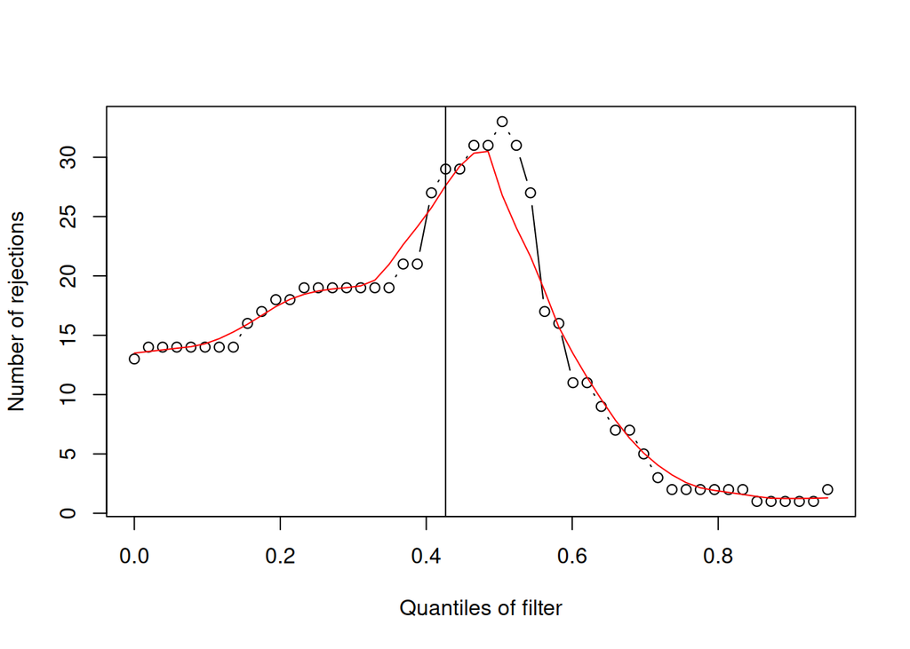

```r
par(mfrow = c(1, 1))
plot(metadata(res)$filterNumRej, type = "b", main = "",
     xlab = "Quantiles of filter", ylab = "Number of rejections")
lines(metadata(res)$lo.fit, col = "red")
abline(v = metadata(res)$filterTheta)
```

#### Histogram of frequency of p-values of results

The following plot shows the number of frequency of counts (y-axis) against p-values between 0 and 1 (x-axis).

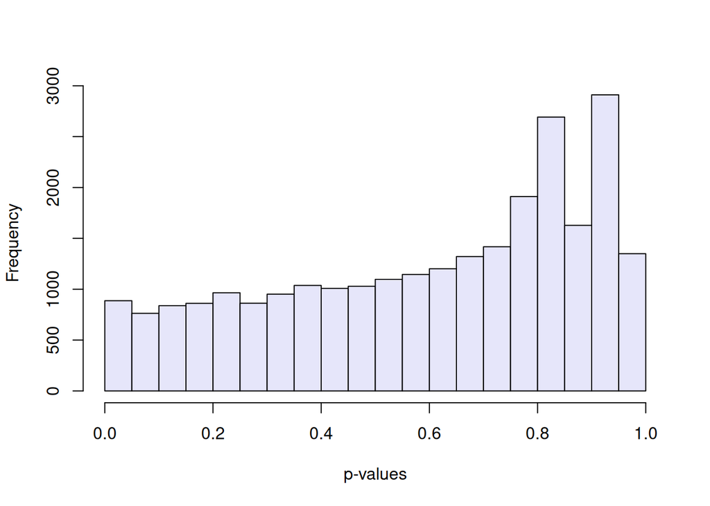

```r
par(mfrow = c(1, 1))
hist(res$pvalue, col = "lavender", xlab = "p-values", main = "")
```

### Numbers of Significant DE genes

*How many significant DE genes upregulated relative to the “IgG” condition and downregulated in PD1 condition?*

```r
res_data %>%
  dplyr::filter(padj < 0.05,
                log2FoldChange > 0) %>%
  nrow()
```

```
#> [1] 26
```

*How many significant DE genes downregulated relative to the “IgG” condition and upregulated in PD1 condition?*

```r
res_data %>%
  dplyr::filter(padj < 0.05,
                log2FoldChange < 0) %>%
  nrow()
```

```
#> [1] 3
```

### Interactive Table of Results

```r
res_data %>%
  dplyr::select(-c(contains("_rep"), contains("_id"), lfcSE, stat)) %>%
  dplyr::mutate(
    log2FoldChange = round(log2FoldChange, 3),
    baseMean       = round(baseMean, 1),
    pvalue         = signif(pvalue, 3),
    padj           = signif(padj, 3)) %>%
  DT::datatable(
  options = list(pageLength = 10),
  caption = "Differential Expression Results: ")
```

|  | gene_name | baseMean | log2FoldChange | pvalue | padj |
| --- | --- | --- | --- | --- | --- |
| 1 | Fbn2 | 840 | 1.767 | 1.77e-24 | 2.63e-20 |
| 2 | Tigit | 181.3 | 1.532 | 1.14e-08 | 7.42e-05 |
| 3 | Krt19 | 43.3 | -3.677 | 1.5e-08 | 7.42e-05 |
| 4 | Tox | 233.3 | 1.605 | 9.05e-08 | 0.000336 |
| 5 | Ctla4 | 125.4 | 1.344 | 1.23e-06 | 0.00364 |
| 6 | Ighg2b | 99.2 | 1.626 | 1.65e-06 | 0.00407 |
| 7 | Il2rb | 1057.1 | 1.214 | 2.76e-06 | 0.00561 |
| 8 | Eln | 829.1 | 1.655 | 3.24e-06 | 0.00561 |
| 9 | Sox2 | 2073.3 | 0.559 | 3.5e-06 | 0.00561 |
| 10 | Col1a1 | 14168.4 | 0.945 | 3.96e-06 | 0.00561 |

[output cut: 25863 more lines]

### MA Plot

An MA plot (log ratio vs. mean average) visualizes the overall changes in gene expression across the normalize count quartiles.

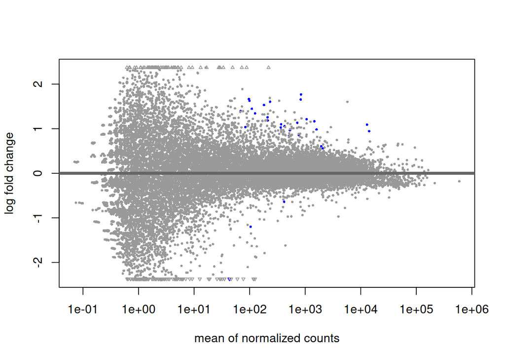

```r
plotMA(res, alpha = 0.05, main = "")
```

### Volcano Plot

A Volcano plot (log2 fold change vs -log10 p-value) helps identify genes that display large magnitude changes and high significance.

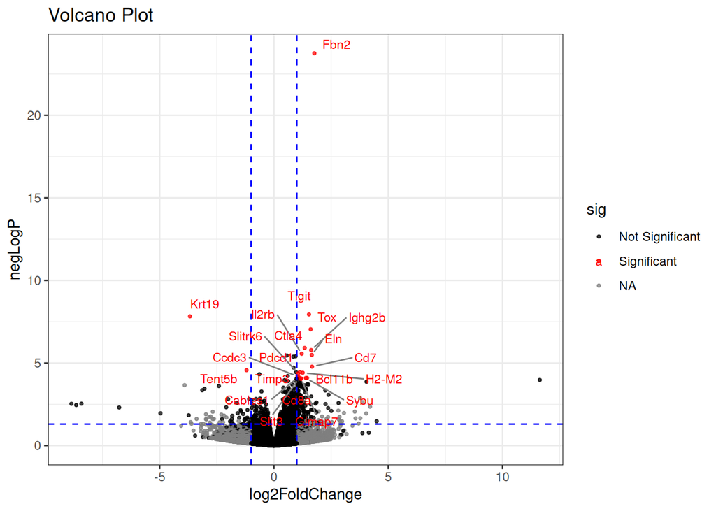

```r
res_data %>%
  dplyr::filter(!is.na(pvalue)) %>%
  dplyr::mutate(
    negLogP = -log10(pvalue),
    sig = ifelse(padj < 0.05 & abs(log2FoldChange) > 1,
                 "Significant", "Not Significant")) -> volcano_data
volcano_data %>%
  ggplot(aes(x = log2FoldChange, y = negLogP, color = sig)) +
  geom_point(size = 0.75, alpha = 0.75) +
  geom_text_repel(data = subset(volcano_data, sig == "Significant"),
                  aes(label = gene_name), size = 3, max.overlaps = Inf,
                  box.padding = 0.3, point.padding = 0.3, segment.color = "grey50") +
  scale_color_manual(values = c("Significant" = "red", "Not Significant" = "black")) +
  geom_hline(yintercept = -log10(0.05), color = "blue", linetype = "dashed") +
  geom_vline(xintercept = c(-1, 1), color = "blue", linetype = "dashed") +
  theme_bw() +
  ggtitle("Volcano Plot")
```

### Count plots

Count plots are created for the top 5 DE genes for each comparison:

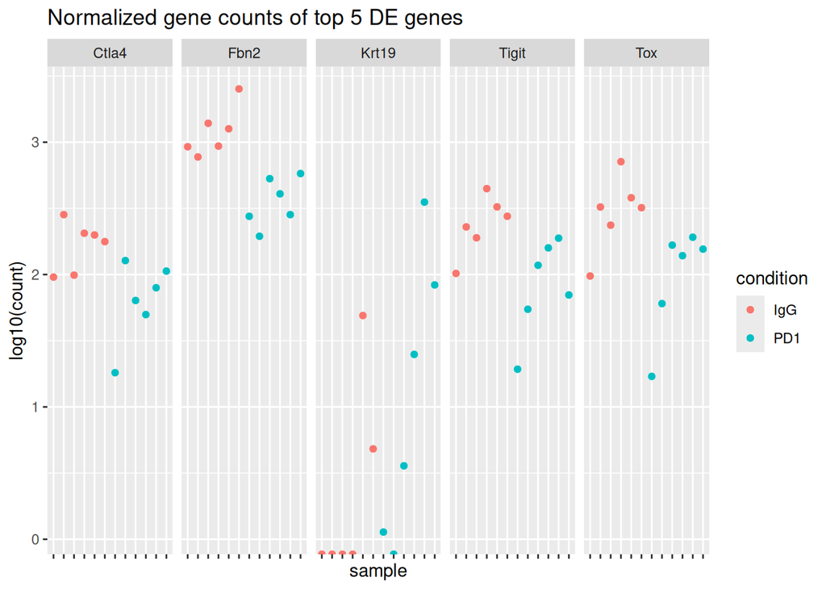

```r
res_data %>%
  dplyr::slice(1:5) %>%
  dplyr::select(gene_name, contains("IgG"), contains("PD1")) %>%
  tidyr::gather(key = "sample", value = "count", -gene_name) %>%
  dplyr::mutate(condition = dplyr::case_when(
                  grepl("IgG", sample) ~ "IgG",
                  grepl("PD1", sample) ~ "PD1"),
                genes = factor(gene_name, levels = unique(gene_name))) %>%
  ggplot(aes(x = sample, y = log10(count), color = condition)) +
  geom_point() +
  theme(axis.text.x = element_blank()) +
  ggtitle(paste0("Normalized gene counts of top 5 DE genes")) +
  facet_grid(~gene_name)
```

### Heatmap

#### Top 20 DE Genes

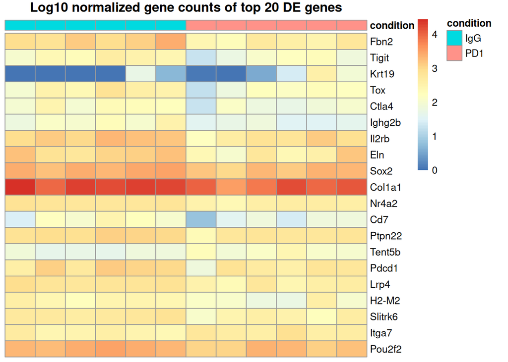

```r
data.frame(condition = meta_data$condition,
           row.names = names(cts)) -> sample_col

res_data %>%
  dplyr::filter(!is.na(gene_name)) %>%
  dplyr::slice(1:20) %>%
  dplyr::select(gene_name, tidyr::contains("IgG"), tidyr::contains("PD1")) %>%
  tibble::column_to_rownames(var = "gene_name") %>%
  mutate(across(everything(), ~ {
    log_vals <- log10(.)
    replace(log_vals, is.infinite(log_vals), 0)})) %>%
  pheatmap::pheatmap(
    annotation_col = sample_col,
    cluster_rows = FALSE,
    cluster_cols = FALSE,
    show_colnames = FALSE,
    main = paste0("Log10 normalized gene counts of top 20 DE genes"))
```

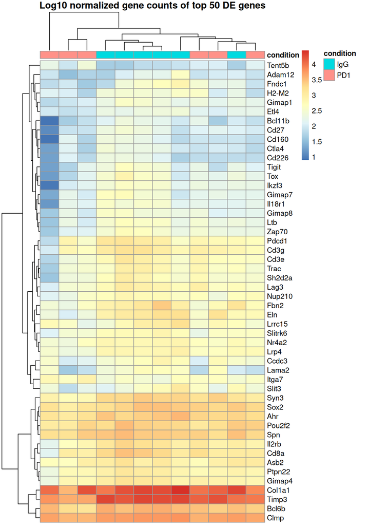

```r
res_data %>%
  dplyr::filter(!is.na(gene_name),
                baseMean > 100) %>%
  dplyr::slice(1:50) %>%
  dplyr::select(gene_name, tidyr::contains("IgG"), tidyr::contains("PD1")) %>%
  tibble::column_to_rownames(var = "gene_name") %>%
  mutate(across(everything(), ~ {
    log_vals <- log10(.)
    replace(log_vals, is.infinite(log_vals), 0)})) %>%
  pheatmap::pheatmap(
    annotation_col = sample_col,
    # cluster_rows = FALSE,
    # cluster_cols = FALSE,
    show_colnames = FALSE,
    # show_rownames = FALSE,
    main = paste0("Log10 normalized gene counts of top 50 DE genes"))
```

## Saving Outputs

The results are saved as `.rds` and `.xlsx` files for downstream use:

```r
# Save DE result object
saveRDS(res_data, file = paste0("./results/", project_name, "_DE_results_",
                                Sys.Date(), ".rds"))

# Save an Excel file
write_xlsx(res_data, path = paste0("./results/", project_name, "_DE_results_",
                                   Sys.Date(), ".xlsx"))
```

## Conclusions and Next Steps

In this analysis, we:

1. Filtered out genes with zero counts.
2. Normalized raw counts to account for varying library sizes.
3. Examined PCA plots, dispersion estimates, and size factors for quality control.
4. Identified significantly differentially expressed genes, focusing on log2 fold changes and adjusted p-values.
5. Annotated results with gene IDs using the Biomart database.
6. Generated various plots illustrating the DE genes between conditions.

Next steps after this DE analysis could include:

1. Functional Analysis: GO/KEGG enrichment of significant genes.
2. Validation: qPCR or other orthogonal methods for top candidate genes.
3. Further QC: Checking for batch effects, outliers, etc.

*References:*

Love, M.I., Huber, W., Anders, S. (2014) “Moderated estimation of fold change and dispersion for RNA-seq data with DESeq2.” Genome Biology, 15:550. 10.1186/s13059-014-0550-8

Anders, Simon, and Wolfgang Huber. 2010. “Differential Expression Analysis for Sequence Count Data.” Genome Biology 11:R106. http://genomebiology.com/2010/11/10/R106.

Ritchie ME, Phipson B, Wu D, Hu Y, Law CW, Shi W, Smyth GK (2015). “limma powers differential expression analyses for RNA-sequencing and microarray studies.” Nucleic Acids Research, 43(7), e47. doi: 10.1093/nar/gkv007.

Van den Berge & Perraudeau *et al* “Observation weights unlock bulk RNA-seq tools for zero inflation and single-cell applications” *Genome Biology* (2018) [doi: 10.1186/s13059-018-1406-4](https://doi.org/10.1186/s13059-018-1406-4)